# Renal Disease Take Home Project Answers

Jonathan Pedroza, JP

10/20/2021

```r
knitr::opts_chunk$set(echo = TRUE)

getwd()
```

```
## [1] "C:/Users/cpppe/Desktop/github_projects/data_visualizations/take_home_to_be_completed"
```

```r
library(tidyverse)
```

## Mentor Milestone 1 (students usually cover this during week 1 + 2)

Import the project data and recreate the ggplot below. Then, extend the milestone by creating another plot to demonstrate your understanding of ggplot.

Step 1: Read in `baseline_data.xpt` (MDRD data) and recreate the plot below.

```r
baseline <- haven::read_xpt(here::here("take_home_to_be_completed", "data/baseline_data.xpt"))

# baseline <- haven::read_xpt("../data/baseline_data.xpt")
```

Recreate the plot in this chunk:

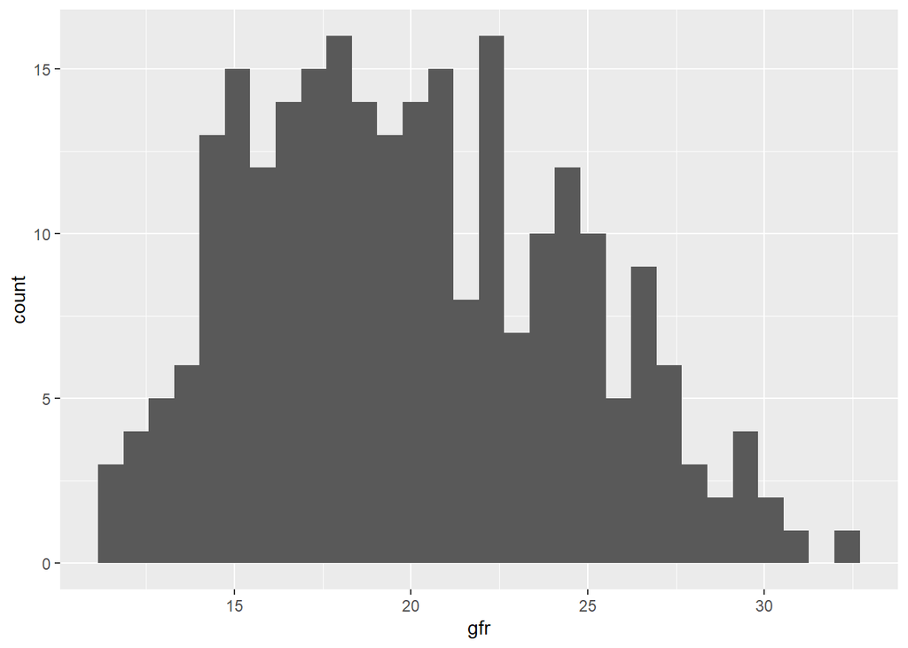

```r
ggplot(data = baseline, aes(gfr)) +
  geom_histogram()
```

Step 2: Create a second plot below:

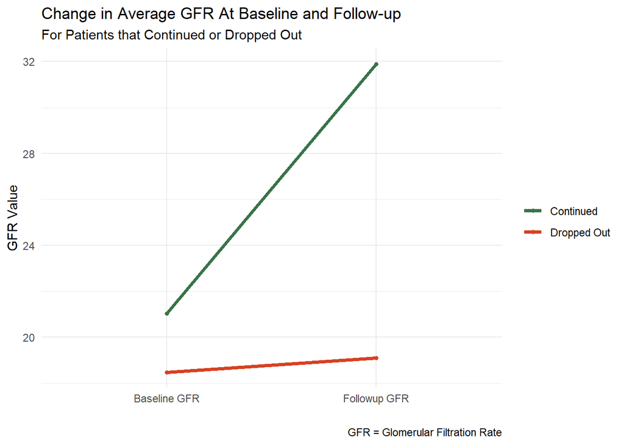

```r
baseline %>%
  pivot_longer(cols = c("gfr", "followup"), names_to = "before_after", values_to = "gfr_values") %>%
  mutate(before_after = factor(before_after),
         dropout = factor(dropout),
         before_after = relevel(before_after, ref = "gfr"),
         dropout = recode(dropout,
                          "0" = "Continued",
                          "1" = "Dropped Out"),
         before_after = recode(before_after,
                               "gfr" = "Baseline GFR",
                               "followup" = "Followup GFR")) %>%
  group_by(dropout, before_after) %>%
  mutate(avg_gfr = mean(gfr_values)) %>%
  ungroup() %>%
  ggplot(aes(before_after, avg_gfr, group = dropout)) +
  geom_line(aes(color = dropout), size = 1.25) +
    geom_point(aes(color = dropout), size = 1.25) +
  labs(title = "Change in Average GFR At Baseline and Follow-up",
       subtitle = "For Patients that Continued or Dropped Out",
       x = "",
       y = "GFR Value",
       caption = "GFR = Glomerular Filtration Rate") +
  scale_color_manual(values = c("#387448", "#d74122")) +
  theme_minimal() +
  theme(legend.title = element_blank())
```

## Mentor Milestone 2

Read in the data from data/baseline_data.xpt and data/data_supplemental.xlsx data_dictionary.md in the data folder explains the variables in both data sets (in case you’d like to learn more about the data) The formula for BMI is kilograms / meters^2 Please do and save your work below:

For your extension, please demonstrate your understanding of summarizing data sets.

```r
supplemental <- readxl::read_xlsx(here::here("take_home_to_be_completed", "data/data_supplemental.xlsx"))

data <- left_join(baseline, supplemental, by = "ptid")

data <- data %>%
  mutate(bmi = weight/height^2)

data %>%
  select(ptid, gfr, age, bmi) %>%
  print()
```

```
## # A tibble: 255 x 4
##     ptid   gfr   age   bmi
##    <dbl> <dbl> <dbl> <dbl>
##  1     1  24.3  80.7  26.6
##  2     2  18.8  73.3  28.1
##  3     3  21.3  63.0  27.1
##  4     4  17.5  75.1  32.5
##  5     5  19.9  61.9  26.7
##  6     6  22.8  75.6  26.3
##  7     7  16.4  70.9  30.5
##  8     8  17.7  71.9  27.5
##  9     9  13.1  76.7  39.8
## 10    10  19.7  74.7  33.9
## # ... with 245 more rows
```

```r
data %>%
  summarize(avg_bmi = mean(bmi, na.rm = TRUE),
            med_bmi = median(bmi),
            variance = sd(bmi)^2,
            sd_bmi = sd(bmi),
            n = n())
```

```
## # A tibble: 1 x 5
##   avg_bmi med_bmi variance sd_bmi     n
##     <dbl>   <dbl>    <dbl>  <dbl> <int>
## 1    28.5    28.5     27.7   5.26   255
```

```r
data %>%
  mutate(dietl_n = recode(dietl_n, "1" = "Yes",
                          "0" = "No")) %>%
  group_by(sex, dietl_n) %>%
  summarize(avg_bmi = mean(bmi, na.rm = TRUE),
            med_bmi = median(bmi),
            variance = sd(bmi)^2,
            sd_bmi = sd(bmi),
            n = n())
```

```
## # A tibble: 4 x 7
## # Groups:   sex [2]
##   sex   dietl_n avg_bmi med_bmi variance sd_bmi     n
##   <chr> <chr>     <dbl>   <dbl>    <dbl>  <dbl> <int>
## 1 F     No         28.5    28.5     31.7   5.63    95
## 2 F     Yes        27.6    27.4     21.7   4.66    30
## 3 M     No         28.6    28.5     29.6   5.44    98
## 4 M     Yes        29.3    29.1     16.6   4.07    32
```

```r
data %>%
  filter(dropout == 0) %>%
  summarize(avg_bmi = mean(bmi, na.rm = TRUE),
            med_bmi = median(bmi),
            variance = sd(bmi)^2,
            sd_bmi = sd(bmi),
            n = n())
```

```
## # A tibble: 1 x 5
##   avg_bmi med_bmi variance sd_bmi     n
##     <dbl>   <dbl>    <dbl>  <dbl> <int>
## 1    27.9    28.4     30.4   5.51   154
```

```r
data %>%
  group_by(dietl_n, dietk_n) %>%
  filter(dietl_n == 1 |
           dietk_n == 1) %>%
  summarize(avg_bmi = mean(bmi, na.rm = TRUE),
            med_bmi = median(bmi),
            variance = sd(bmi)^2,
            sd_bmi = sd(bmi),
            n = n())
```

```
## # A tibble: 2 x 7
## # Groups:   dietl_n [2]
##   dietl_n dietk_n avg_bmi med_bmi variance sd_bmi     n
##     <dbl>   <dbl>   <dbl>   <dbl>    <dbl>  <dbl> <int>
## 1       0       1    29.1    28.9     29.3   5.41    61
## 2       1       0    28.4    28.5     19.5   4.41    62
```

```r
data %>%
  pivot_longer(cols = c("dietl_n", "dietl_l", "dietk_n", "dietk_l"), names_to = "diet_assignment", values_to = "diet_values") %>%
  filter(diet_assignment == "dietl_n") %>%
  summarize(avg_bmi = mean(bmi, na.rm = TRUE),
            med_bmi = median(bmi),
            variance = sd(bmi)^2,
            sd_bmi = sd(bmi),
            n = n())
```

```
## # A tibble: 1 x 5
##   avg_bmi med_bmi variance sd_bmi     n
##     <dbl>   <dbl>    <dbl>  <dbl> <int>
## 1    28.5    28.5     27.7   5.26   255
```

## Mentor Milestone 3 (students usually cover this during week 9)

This milestone is about iteration with `purrr`. Your objective is to use iteration to load in the 100 files found in the `/data/milestone-3` directory.

Please do and save your work below:

```r
data_files <- fs::dir_ls(here::here("take_home_to_be_completed/data", "milestone-3"),
                         glob = "*.csv")

data_combined <-map_dfr(data_files, read_csv)
```

```r
head(data_combined, 10)
```

```
## # A tibble: 10 x 2
##       id treatment
##    <dbl> <chr>
##  1     1 dietk_l
##  2     2 dietl_n
##  3     3 dietl_l
##  4     4 dietk_l
##  5     5 dietk_l
##  6     6 dietl_n
##  7     7 dietl_l
##  8     8 dietk_l
##  9     9 dietk_l
## 10    10 dietk_n
```

For your milestone extension, please choose from the following 2 options:

- Explain the difference between `map()` and its variants, such as `map_chr()`.

**Answer**: The difference between `map()` and its variants is that `map()` will always return a list, while the variants will return the appropriate vector depending on the variant function. For instance, `map_chr()` will return a character vector if working with strings.

- Share an example of how you’ve used `purrr` in the past.